# Session 7: Sampling Distribution

Mobina Pourmoshir

3/1/2024

### Statistics and Sampling Variability

- Statistic: A quantity computed from values in a sample.
  - Given a sample from a population, the sample mean, sample proportion, or sample standard deviation computed from this sample are examples of statistic.
- Sampling Variability: The observed value of a statistic depends on the particular sample selected from the population and it will vary from sample to sample. This variability is called sampling variability.
- Sampling Distribution: A sampling distribution is a probability distribution of a certain statistic based on many random samples from a single population.
  - Sampling distribution of sample mean, sample proportion, sample standard deviation.

# Sampling Variability

### Example CEO Salary Dataset

- The data set CEO_Salary_2012.csv contains the annual salary (in $Million) information of 497 CEO’s in 2012.
- The data is from the book Stats: Data and Models (2014) by De Veaux, Velleman, and Bock.
- We consider the data CEO_Salary_2012.csv as population data of 497 CEO’s annual salary.

```r
ceo_salary <- read.csv("C:/Users/PC/Desktop/Spring 2024/MATH 4730 Introduction to R/data_sets/CEO_Salary_2012.csv",header=TRUE)
str(ceo_salary)
```

```
## 'data.frame':    497 obs. of  5 variables:
##  $ ï..Rank   : int  1 2 3 4 5 6 7 8 9 10 ...
##  $ Name      : chr  "John H Hammergren" "Ralph Lauren" "Michael D Fascitelli" "Richard D Kinder" ...
##  $ Company   : chr  "McKesson" "Ralph Lauren" "Vornado Realty" "Kinder Morgan" ...
##  $ Annual.pay: num  131.2 66.7 64.4 60.9 55.8 ...
##  $ Age       : int  53 72 55 67 59 57 55 59 61 60 ...
```

```r
head(ceo_salary)
```

```
##   ï..Rank                 Name         Company Annual.pay Age
## 1       1    John H Hammergren        McKesson    131.190  53
## 2       2         Ralph Lauren    Ralph Lauren     66.650  72
## 3       3 Michael D Fascitelli  Vornado Realty     64.405  55
## 4       4     Richard D Kinder   Kinder Morgan     60.940  67
## 5       5         David M Cote       Honeywell     55.790  59
## 6       6           George Paz Express Scripts     51.525  57
```

# Sampling Variability

### Exploring Dataset

- We set our focus on the variable `Annual.pay`.
- `Annual.pay` is the 1 Year Pay ($Million) of the 497 CEO’s in this population.

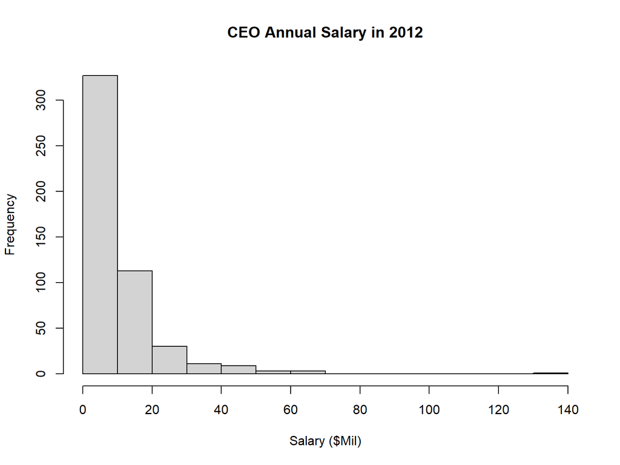

```r
hist(ceo_salary$Annual.pay, main = "CEO Annual Salary in 2012",xlab = "Salary ($Mil)")
```

- The shape of the population salary histogram is skewed to the right meaning that some CEO’s have very large salaries compared to the rest.

```r
mu <- mean(ceo_salary$Annual.pay)
mu
```

```
## [1] 10.53906
```

```r
sigma <- sd(ceo_salary$Annual.pay)
sigma
```

```
## [1] 11.46751
```

```r
summary(ceo_salary$Annual.pay)
```

```
##    Min. 1st Qu.  Median    Mean 3rd Qu.    Max.
##    0.16    3.91    6.97   10.54   13.37  131.19
```

- The population salary mean is $10.539$ `Mil` and population salary standard deviation is $11.468$ `Mil`.

# Sampling Variability

### Generating random sample and computing statistics

- Next we select 3 random sample of 5 CEO’s each and compute the respective sample mean salary.

```r
set.seed(123456)
s1 <- sample(ceo_salary$Annual.pay,5)
xbar1 <- mean(s1)
sd1 <- sd(s1)
xbar1
```

```
## [1] 13.884
```

```r
sd1
```

```
## [1] 8.567493
```

```r
s2 <- sample(ceo_salary$Annual.pay,5)
xbar2 <- mean(s2)
sd2 <- sd(s2)
xbar2
```

```
## [1] 8.159
```

```r
sd2
```

```
## [1] 0.9166815
```

```r
s3 <- sample(ceo_salary$Annual.pay,5)
xbar3 <- mean(s3)
sd3 <- sd(s3)
xbar3
```

```
## [1] 20.523
```

```r
sd3
```

```
## [1] 25.45455
```

- The sample means for each randomly generated sample are $13.88, 8.16, 20.52$ `Mil`.
- These means are significantly different from the population mean $10.539$ `Mil`.
- There is also significant variability in the sample standard deviation for each randomly generated sample.

# Sampling Variability

### Sampling Disribution

- We generate 1000 random samples each of size 5 and compute the sample means and sample standard deviations.

```r
n <-  1000 # The number of samples
samples <- matrix(NA,nrow=5,ncol=n)
for (j in 1:n) samples[,j] <- sample(ceo_salary$Annual.pay,5)
samples_means <- apply(samples,2,mean)
# true mean, and average of the sample means
mu.xbar <- mean(samples_means)
c(mu, mu.xbar)
```

```
## [1] 10.53906 10.60135
```

```r
# true standard deviation, and standard deviation of the sample means
std.xbar <- sd(samples_means)
c(sigma, std.xbar)
```

```
## [1] 11.467507  5.175263
```

```r
sigma/sqrt(5)
```

```
## [1] 5.128425
```

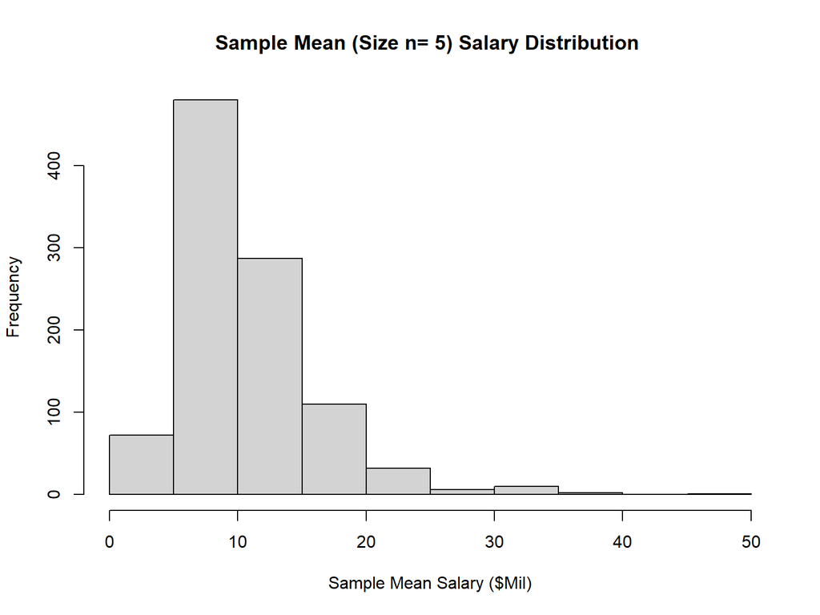

```r
hist(samples_means,main = "Sample Mean (Size n= 5) Salary Distribution ",xlab = "Sample Mean Salary ($Mil)")
```

- The figure above is a histogram of the 1000 sample mean salaries computed from 1000 samples each of size n = 5.
- This histogram provides insight about the behavior of sample mean salary.
- For a sample of size n = 5, the shape of the density histogram of the sample mean salary is skewed to the right similar to, although not as pronounced, as the histogram of the population salary.

# Sampling Disribution of Sample Mean

- Sampling distribution: The distribution that would be formed by considering the value of a sample statistic for every possible different sample of a given size from a population.
- What happens when the sample size is increased?
- In the code chunk below, we generate 1000 random sample each of sizes 10,30, and 50. We compute the means of each random sample visualize the distribution of the sample means per sample size.

```r
m <- c(10,30,50)
n <- 1000
samples <- list()
for (i in 1:length(m)){
  samples[[i]] <- matrix(NA,nrow=m[i],ncol=n)
  for (j in 1:n){
    samples[[i]][,j] <- sample(ceo_salary$Annual.pay,m[i])
  }
}
sn10 <- apply(samples[[1]],2,mean)
sn30 <- apply(samples[[2]],2,mean)
sn50 <- apply(samples[[3]],2,mean)

lapply(samples, mean)
```

```
## [[1]]
## [1] 10.40184
##
## [[2]]
## [1] 10.53481
##
## [[3]]
## [1] 10.55719
```

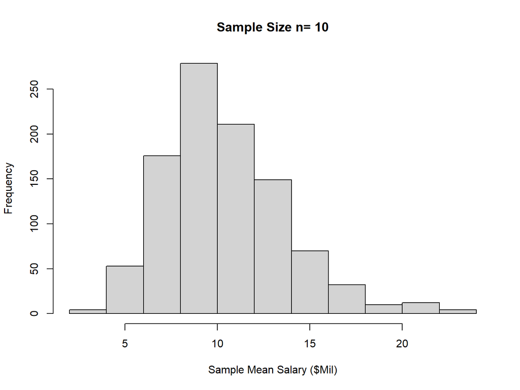

```r
hist(sn10,main = "Sample Size n= 10",xlab = "Sample Mean Salary ($Mil)")
```

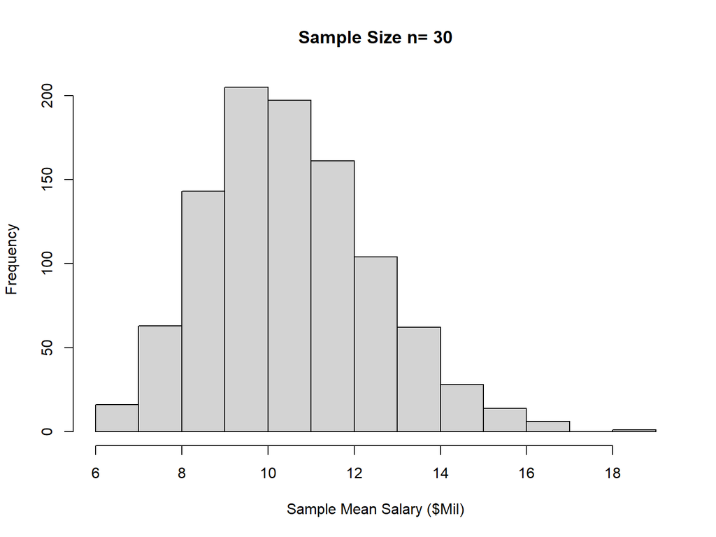

```r
hist(sn30,main = "Sample Size n= 30",xlab = "Sample Mean Salary ($Mil)")
```

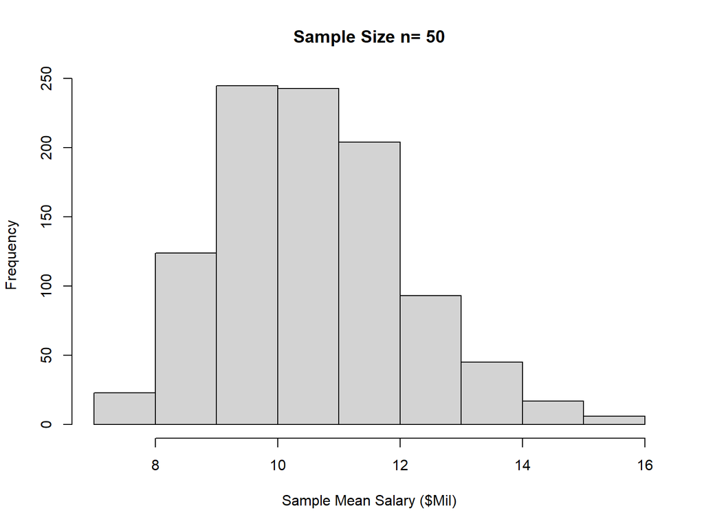

```r
hist(sn50,main = "Sample Size n= 50",xlab = "Sample Mean Salary ($Mil)")
```

# Properties of the Sampling Distribution of the Mean

- The following are properties of the sample means when they are computed from randomly selected samples.
  1. The average of the sample means is the true (population) mean.
  2. The standard deviation of the sample means is the true (population) standard deviation divided by the square root of the sample size.
  3. If the original population is normal, the sampling distribution of the sample mean is also normal.
  4. Central Limit Theorem: If the sample size n is sufficiently large, the sampling distribution of the sample mean can be approximated by the normal distribution.

### Central Limit Theorem (CLT)

- Example: We observed clearly that our original population of Annual salary is not normally distributed.
- As a result of the CLT, we can perform normal probability calculations involving the sample mean salary when the sample size is sufficiently large.
- The usual cut-off for a large sample size is $n=30$.
- When a sample of 50 CEO’s is randomly selected from the data ceo_salary, we can compute the following:
  - 1. probability that the sample mean salary is below $\$11$ `Mil`.
  - 2. probability that the sample mean salary is between $\$10$ `Mil` and $\$11$ `Mil`.

```r
pnorm(q = 11, mean = mu, sd = sigma/sqrt(50))
```

```
## [1] 0.6118795
```

- The probability that the sample mean salary is below $\$11$ `Mil` is $0.6119$

```r
pnorm(q = 11, mean = mu, sd = sigma/sqrt(50)) - pnorm(q = 10, mean = mu, sd = sigma/sqrt(50))
```

```
## [1] 0.2420846
```

- The probability that the sample mean salary is between $\$10$ `Mil` and $\$11$ `Mil` is $0.2421$

# Sampling Distribution of Sample Proportion.

- Just like sample means, we can compute the sample proportions, visualize the distribution of the sample proportions and make some calculations.
- The distribution of sample proportions is known as the sampling distribution of the proportion and has the following properties:
  - $\mu_p = P$; where $p$ is sample proportion and $P$ is population proportion.
  - $\sigma_p = \sqrt{\frac{P(1-P)}{n}}$; where $P$ is population proportion and $n$ is the sample size.
- The properties stated above are valid if the sampling distribution is approximately normal.
- The sampling distribution of a sample proportion is approximately normal if the expected number of successes and failures are both at least 10. That is $n*P \geq 10$ and $n*(1-P) \geq 10$.

# Sampling Distribution of Sample Standard Deviation

- Again, we can compute sample standard deviations and visualize the distribution of the sampling distributions.
- In general, when samples of size $n$ are taken from a **normal distribution** with population variance $\sigma^2$ , the sampling distribution of the $(n-1)S^2/ \sigma^2$ has a chi-square distribution with $n-1$ degrees of freedom.
- We can then compute probabilities using `qchisq()`.

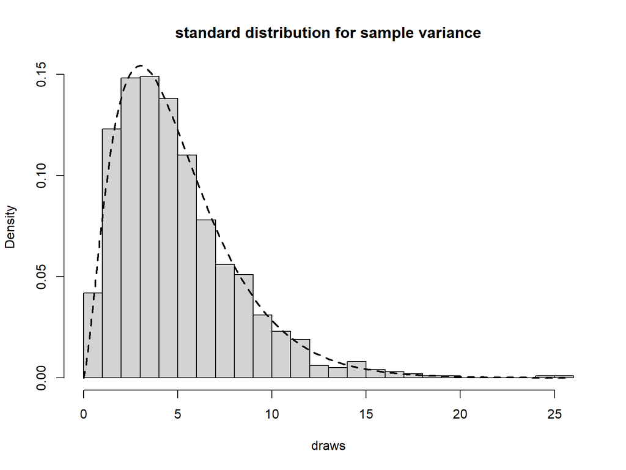

```r
draws = matrix(rnorm(1000 * 6, 0, 3), 6)
drawvar = apply(draws, 2, var)


draws = 5 * drawvar/9
hist(draws, breaks = 20, prob = TRUE, main = "standard distribution for sample variance")
v = seq(0, max(draws), length = 200)
lines(v, dchisq(v, 5), lty = 2, lwd = 2)
```

# Sampling Variability

### Deleting outliers

- Using the interquartile range to find outliers
  1. Sort your data from low to high
  2. Identify the median, the first quartile (Q1), and the third quartile (Q3)
  3. Calculate your IQR. `IQR = Q3 - Q1`
  4. Calculate your upper fence. `UF = Q3 + 1.5*IQR`
  5. Calculate your lower fence. `LF = Q1 - 1.5*IQR`
  6. Use your fences to highlight any outliers, all values that fall outside your fences.

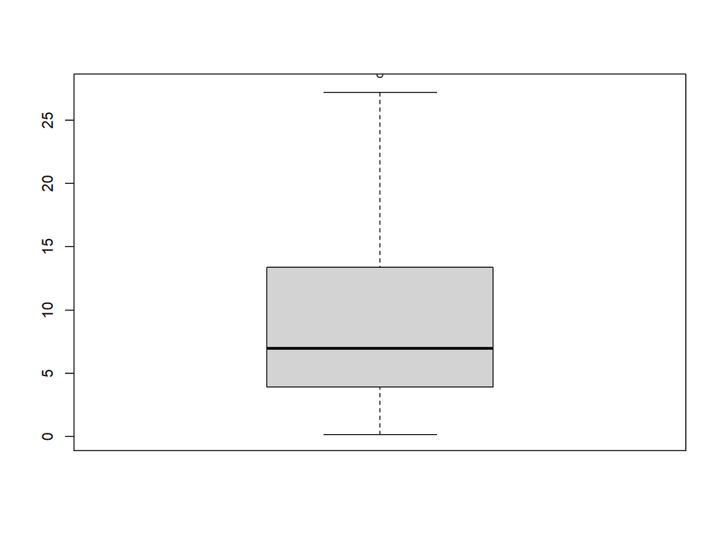

```r
# Deleting outliers
#find Q1, Q3, and interquartile range for values in column A
Q1 <- quantile(ceo_salary$Annual.pay, .25)
Q3 <- quantile(ceo_salary$Annual.pay, .75)
IQR <- IQR(ceo_salary$Annual.pay)
boxplot(ceo_salary$Annual.pay,ylim=c(0,(Q3 + 1.5*IQR)))
```

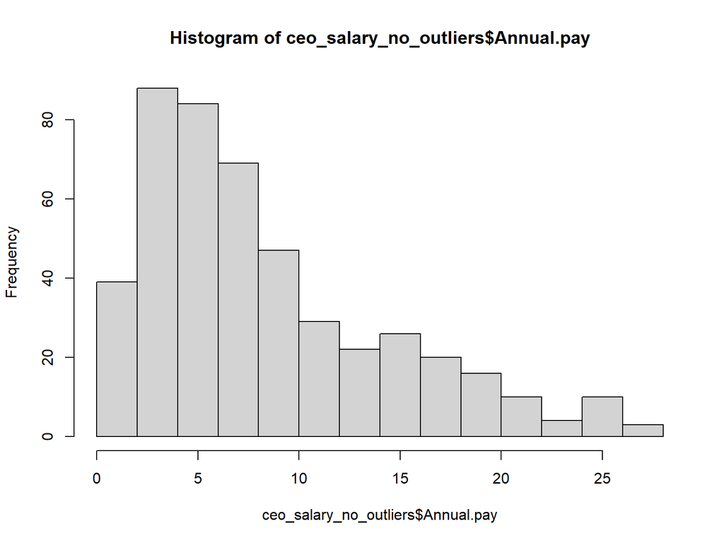

```r
#only keep rows in dataframe that have values within 1.5*IQR of Q1 and Q3
ceo_salary_no_outliers <- subset(ceo_salary, ceo_salary$Annual.pay > (Q1 - 1.5*IQR)
                                 & ceo_salary$Annual.pay < (Q3 + 1.5*IQR))

hist(ceo_salary_no_outliers$Annual.pay)
```